# Lab 4

Luna Herschenfeld-Catalán

2024-04-24

Lab 4 Assignment: Due May 7 at 11:59pm

1. Select another classification algorithm.

I am going to do a random forest for the classification algorithm.

Preprocessing:

```r
# load in data
urlfile ="https://raw.githubusercontent.com/MaRo406/EDS-231-text-sentiment/main/data/climbing_reports_model_dat.csv"
incidents_df<-readr::read_csv(url(urlfile))

# split data
set.seed(1234)

incidents2class <- incidents_df %>%
  mutate(fatal = factor(ifelse(is.na(Deadly),
                               "non-fatal",
                               "fatal")))

# look at the distribution of fatal and non-fatal
table(incidents2class$fatal)
```

```
##
##     fatal non-fatal
##       563      2207
```

```r
incidents_split <- initial_split(incidents2class,
                                 strata = fatal) # samples equally from each group

incidents_train <- training(incidents_split)
incidents_test <- testing(incidents_split)

incidents_rec <- recipe(fatal ~ Text, data = incidents_train)

# create recipe
recipe <- incidents_rec %>%
  step_tokenize(Text) %>%
  step_tokenfilter(Text, max_tokens = 1000) %>%  # only use 1000 words
  step_tfidf(Text)#coming from text recipes
```

2. Conduct an initial out-of-the-box model fit on the training data and prediction on the test data. Assess the performance of this initial model.

```r
# create specification - add mode and engine (random forest)
rf_spec <- rand_forest() %>%
  set_mode("classification") %>%
  set_engine("ranger")
```

```r
# create workflow
rf_wf <- workflow() %>%
  add_recipe(recipe) %>%
  add_model(rf_spec)
```

```r
# create folds
set.seed(1234)
incidents_folds <- vfold_cv(incidents_train)

# estimate performance using resampling
rf_rs <- fit_resamples(
  rf_wf,
  incidents_folds,
  control = control_resamples(save_pred = T)
)
```

```r
# collect metrics and predictions
rf_rs_metrics <- collect_metrics(rf_rs)
rf_rs_predictions <- collect_predictions(rf_rs)

rf_rs_metrics
```

```
## # A tibble: 2 × 6
##   .metric  .estimator  mean     n std_err .config
##   <chr>    <chr>      <dbl> <int>   <dbl> <chr>
## 1 accuracy binary     0.861    10 0.00950 Preprocessor1_Model1
## 2 roc_auc  binary     0.954    10 0.00406 Preprocessor1_Model1
```

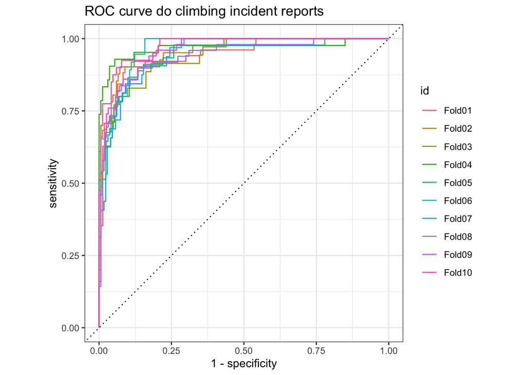

```r
rf_rs_predictions %>%
  group_by(id) %>%
  roc_curve(truth = fatal,
            .pred_fatal) %>%
  autoplot() +
  labs("Resampling",
       title = "ROC curve do climbing incident reports")
```

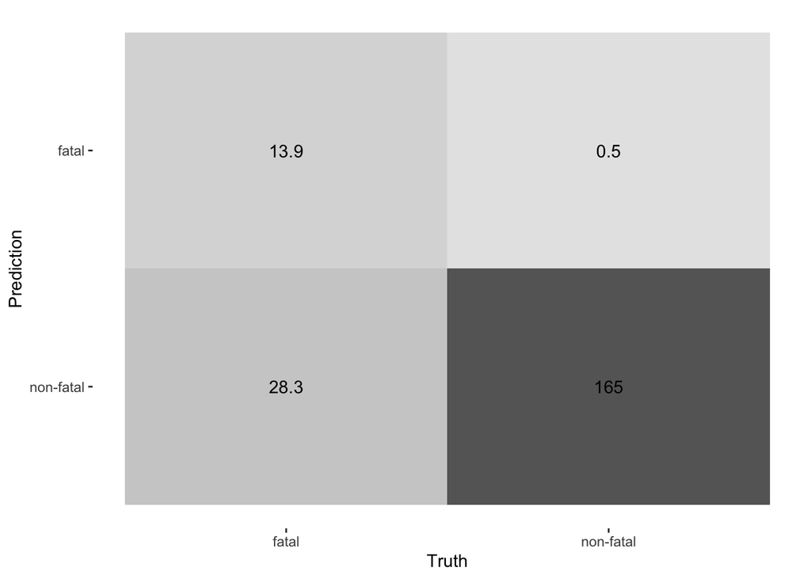

```r
conf_mat_resampled(rf_rs, tidy = F) %>%
  autoplot(type = "heatmap")
```

3. Select the relevant hyperparameters for your algorithm and tune your model.

```r
# redefine incidents
incidents_folds <- vfold_cv(incidents_train, v = 5)

# tune parameters
rf_spec_tune <- rand_forest(mtry = tune(),
                        trees = tune()) %>%
  set_engine("ranger", importance = "impurity") %>%
  set_mode("classification") # the output is cover type

# create workflow with feature recipe
rf_wf_tune <- workflow() %>%
  add_model(rf_spec_tune) %>%
  add_recipe(recipe)
```

This took a long time so I exported it to an .rda file:

```r
doParallel::registerDoParallel(cores = 4)

# this is taking a r
system.time(
  rf_tune <- rf_wf_tune %>%
    tune_grid(
      resamples = incidents_folds, # add folds
      grid = 5 # number of combos of mtry and trees
    )
)

write_rds(rf_tune, "rf_tune.rda")
```

4. Conduct a model fit using your newly tuned model specification. How does it compare to your out-of-the-box model?

```r
rf_tune <- read_rds("rf_tune.rda")

rf_final = finalize_workflow(rf_wf_tune,
                             select_best(rf_tune, metric = "roc_auc"))

rf_rs_tune <- fit_resamples(
  rf_final,
  incidents_folds,
  control = control_resamples(save_pred = T)
)

# collect metrics and predictions
rf_rs_tune_metrics <- collect_metrics(rf_rs_tune)
rf_rs_tune_predictions <- collect_predictions(rf_rs_tune)

rf_rs_tune_metrics
```

```
## # A tibble: 2 × 6
##   .metric  .estimator  mean     n std_err .config
##   <chr>    <chr>      <dbl> <int>   <dbl> <chr>
## 1 accuracy binary     0.913     5 0.00517 Preprocessor1_Model1
## 2 roc_auc  binary     0.928     5 0.00637 Preprocessor1_Model1
```

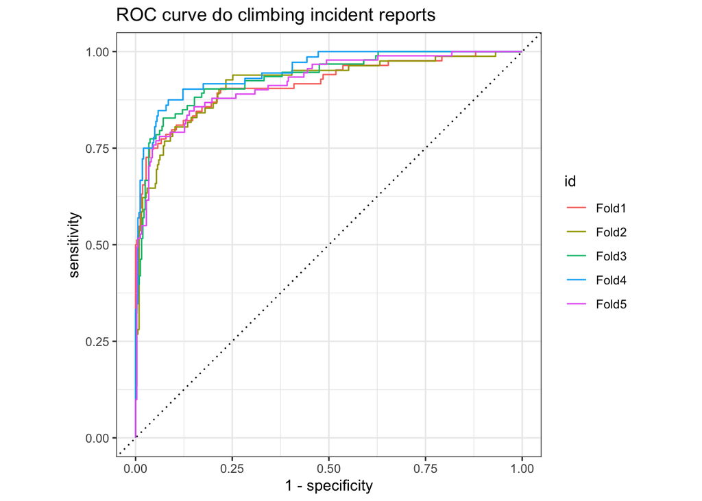

```r
rf_rs_tune_predictions %>%
  group_by(id) %>%
  roc_curve(truth = fatal,
            .pred_fatal) %>%
  autoplot() +
  labs("Random Forest Tuned Resampling",
       title = "ROC curve do climbing incident reports")
```

5. 1. Use variable importance to determine the terms most highly associated with non-fatal reports? What about terms associated with fatal reports? OR
   2. If you aren’t able to get at variable importance with your selected algorithm, instead tell me how you might in theory be able to do it. Or how you might determine the important distinguishing words in some other way.

   You could look at how associated each word is with the classification as fatal.

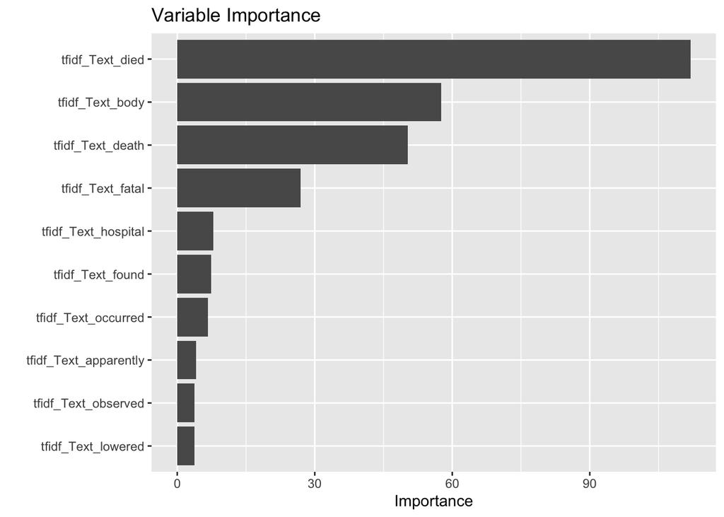

```r
#fit the random forest model to the training set and extract variable importance
fatal_vip <- fit(rf_final, incidents_train) %>%
  extract_fit_parsnip() %>%
  vip::vip() +
  labs(title = "Variable Importance")

fatal_vip
```

6. Predict fatality of the reports in the test set. Compare this prediction performance to that of the Naive Bayes and Lasso models. Why do you think your model performed as it did, relative to the other two?

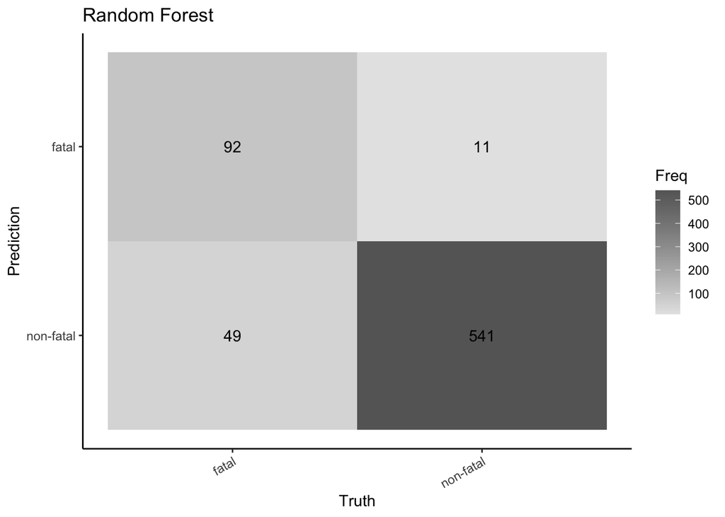

```r
# fit final worlkflow to training data
rf_fit <- fit(rf_final, incidents_train)

# fit the final worrkflow to the test data
test_predict_rf <- predict(rf_fit, incidents_test) %>% #get testing prediction
  bind_cols(incidents_test) %>%  #bind to testing column
  mutate(fatal = as.factor(fatal))

test_predict_rf %>%
  conf_mat(truth = fatal, estimate = .pred_class) %>% #create confusion matrix
  autoplot(type = "heatmap") + #plot confusion matrix with heatmap
  theme_classic() +
  theme(axis.text.x = element_text(angle = 30, hjust=1)) +
  #rotate axis labels
  labs(title = "Random Forest")
```

The Naive-bayes: - accuracy: 0.799 - roc_auc: 0.729

Lasso: - accuracy: 0.916 - roc_auc: 0.950

**The Random forest performed adequately on this data, better than the Naive-Bayes and worse than the lasso. However, the RF took much longer to process than either of the other models and I would be detered since its performance was not as fast as the Lasso and it did not perform as well. I think Naive-Bayes did not perform well because it assumes the independence of the appearance of words and thet decreased its effectivness at this task since there were associations. The RF performed well because there was a lot of data to process and the ease of binary classification.**